# AUS RAIN DATA

# Installs n Imports

```r
install.packages("pROC")
install.packages("car")
install.packages("caTools")
install.packages("tidyverse")
library(pROC)
library(car)
library(caTools)
library(ggplot2)
library(plotly)
library(tidyverse)
install.packages("corrplot")
library(corrplot)
install.packages(c("rpart", "rpart.plot", "e1071", "randomForest", "AppliedPredictiveModeling", "caret", "ROCR"))
library(rpart) #This one is for building decision trees
library(rpart.plot)
library(e1071)
library(randomForest)
library(ROCR)
library(caret)
```

# Make it rain

```r
ausdata <- read.csv("weatherAUS.csv")
head(ausdata)
```

|  | Date | Location | MinTemp | MaxTemp | Rainfall | Evaporation | Sunshine | WindGustDir | WindGustSpeed | WindDir9am | WindDir3pm | WindSpeed9am | WindSpeed3pm | Humidity9am | Humidity3pm | Pressure9am | Pressure3pm | Cloud9am | Cloud3pm | Temp9am | Temp3pm | RainToday | RISK_MM | RainTomorrow |
| --- | --- | --- | --- | --- | --- | --- | --- | --- | --- | --- | --- | --- | --- | --- | --- | --- | --- | --- | --- | --- | --- | --- | --- | --- |
| 1 | 2008-12-01 | Albury | 13.4 | 22.9 | 0.6 | NA | NA | W | 44 | W | WNW | 20 | 24 | 71 | 22 | 1007.7 | 1007.1 | 8 | NA | 16.9 | 21.8 | No | 0.0 | No |
| 2 | 2008-12-02 | Albury | 7.4 | 25.1 | 0.0 | NA | NA | WNW | 44 | NNW | WSW | 4 | 22 | 44 | 25 | 1010.6 | 1007.8 | NA | NA | 17.2 | 24.3 | No | 0.0 | No |
| 3 | 2008-12-03 | Albury | 12.9 | 25.7 | 0.0 | NA | NA | WSW | 46 | W | WSW | 19 | 26 | 38 | 30 | 1007.6 | 1008.7 | NA | 2 | 21.0 | 23.2 | No | 0.0 | No |
| 4 | 2008-12-04 | Albury | 9.2 | 28.0 | 0.0 | NA | NA | NE | 24 | SE | E | 11 | 9 | 45 | 16 | 1017.6 | 1012.8 | NA | NA | 18.1 | 26.5 | No | 1.0 | No |
| 5 | 2008-12-05 | Albury | 17.5 | 32.3 | 1.0 | NA | NA | W | 41 | ENE | NW | 7 | 20 | 82 | 33 | 1010.8 | 1006.0 | 7 | 8 | 17.8 | 29.7 | No | 0.2 | No |
| 6 | 2008-12-06 | Albury | 14.6 | 29.7 | 0.2 | NA | NA | WNW | 56 | W | W | 19 | 24 | 55 | 23 | 1009.2 | 1005.4 | NA | NA | 20.6 | 28.9 | No | 0.0 | No |

# Sumarry

```r
summary(ausdata)
```

```
         Date            Location         MinTemp         MaxTemp
 2013-03-02:    49   Canberra:  3418   Min.   :-8.50   Min.   :-4.80
 2013-03-03:    49   Sydney  :  3337   1st Qu.: 7.60   1st Qu.:17.90
 2013-03-04:    49   Perth   :  3193   Median :12.00   Median :22.60
 2013-03-06:    49   Darwin  :  3192   Mean   :12.19   Mean   :23.23
 2013-03-07:    49   Hobart  :  3188   3rd Qu.:16.80   3rd Qu.:28.20
 2013-03-10:    49   Brisbane:  3161   Max.   :33.90   Max.   :48.10
 (Other)   :141899   (Other) :122704   NA's   :637     NA's   :322
    Rainfall       Evaporation        Sunshine      WindGustDir
 Min.   :  0.00   Min.   :  0.00   Min.   : 0.00   W      : 9780
 1st Qu.:  0.00   1st Qu.:  2.60   1st Qu.: 4.90   SE     : 9309
 Median :  0.00   Median :  4.80   Median : 8.50   E      : 9071
 Mean   :  2.35   Mean   :  5.47   Mean   : 7.62   N      : 9033
 3rd Qu.:  0.80   3rd Qu.:  7.40   3rd Qu.:10.60   SSE    : 8993
 Max.   :371.00   Max.   :145.00   Max.   :14.50   (Other):86677
 NA's   :1406     NA's   :60843    NA's   :67816   NA's   : 9330
 WindGustSpeed      WindDir9am      WindDir3pm     WindSpeed9am
 Min.   :  6.00   N      :11393   SE     :10663   Min.   :  0
 1st Qu.: 31.00   SE     : 9162   W      : 9911   1st Qu.:  7
 Median : 39.00   E      : 9024   S      : 9598   Median : 13
 Mean   : 39.98   SSE    : 8966   WSW    : 9329   Mean   : 14
 3rd Qu.: 48.00   NW     : 8552   SW     : 9182   3rd Qu.: 19
 Max.   :135.00   (Other):85083   (Other):89732   Max.   :130
 NA's   :9270     NA's   :10013   NA's   : 3778   NA's   :1348
  WindSpeed3pm    Humidity9am      Humidity3pm      Pressure9am
 Min.   : 0.00   Min.   :  0.00   Min.   :  0.00   Min.   : 980.5
 1st Qu.:13.00   1st Qu.: 57.00   1st Qu.: 37.00   1st Qu.:1012.9
 Median :19.00   Median : 70.00   Median : 52.00   Median :1017.6
 Mean   :18.64   Mean   : 68.84   Mean   : 51.48   Mean   :1017.7
 3rd Qu.:24.00   3rd Qu.: 83.00   3rd Qu.: 66.00   3rd Qu.:1022.4
 Max.   :87.00   Max.   :100.00   Max.   :100.00   Max.   :1041.0
 NA's   :2630    NA's   :1774     NA's   :3610     NA's   :14014
  Pressure3pm        Cloud9am        Cloud3pm        Temp9am
 Min.   : 977.1   Min.   :0.00    Min.   :0.0     Min.   :-7.20
 1st Qu.:1010.4   1st Qu.:1.00    1st Qu.:2.0     1st Qu.:12.30
 Median :1015.2   Median :5.00    Median :5.0     Median :16.70
 Mean   :1015.3   Mean   :4.44    Mean   :4.5     Mean   :16.99
 3rd Qu.:1020.0   3rd Qu.:7.00    3rd Qu.:7.0     3rd Qu.:21.60
 Max.   :1039.6   Max.   :9.00    Max.   :9.0     Max.   :40.20
 NA's   :13981    NA's   :53657   NA's   :57094   NA's   :904
    Temp3pm      RainToday        RISK_MM        RainTomorrow
 Min.   :-5.40   No  :109332   Min.   :  0.000   No :110316
 1st Qu.:16.60   Yes : 31455   1st Qu.:  0.000   Yes: 31877
 Median :21.10   NA's:  1406   Median :  0.000
 Mean   :21.69                 Mean   :  2.361
 3rd Qu.:26.40                 3rd Qu.:  0.800
 Max.   :46.70                 Max.   :371.000
 NA's   :2726
```

# Column names

```r
colnames(ausdata)
```

```
 [1] "Date"          "Location"      "MinTemp"       "MaxTemp"
 [5] "Rainfall"      "Evaporation"   "Sunshine"      "WindGustDir"
 [9] "WindGustSpeed" "WindDir9am"    "WindDir3pm"    "WindSpeed9am"
[13] "WindSpeed3pm"  "Humidity9am"   "Humidity3pm"   "Pressure9am"
[17] "Pressure3pm"   "Cloud9am"      "Cloud3pm"      "Temp9am"
[21] "Temp3pm"       "RainToday"     "RISK_MM"       "RainTomorrow"
```

# Initial observations with predicitions

Multiple columns can be used to predict things and determine things.

Big hint was weather there would be RainTomorrow.. and how accurate this would be.

Meant to use Classifcation

Personal Note - DO NOT LOOK at CORRELATION

Initial Prediction =

Looking at trends later.. Initial to look at this in better light. 1. Brisbane has faster wind than the rest of austrailia

Expand this further 2. Comparison between rainToday and rainTomorrow

3. Decision Trees to determine how reliable RainTomorrow would be.

RainTomorrow = Boolean. Yes No look how it is done on Classification module for R..

# inital play

Initial plot

```r
qplot(x = ausdata$Date , y = ausdata$WindGustSpeed, col = ausdata$Location)
```

[output not shown]

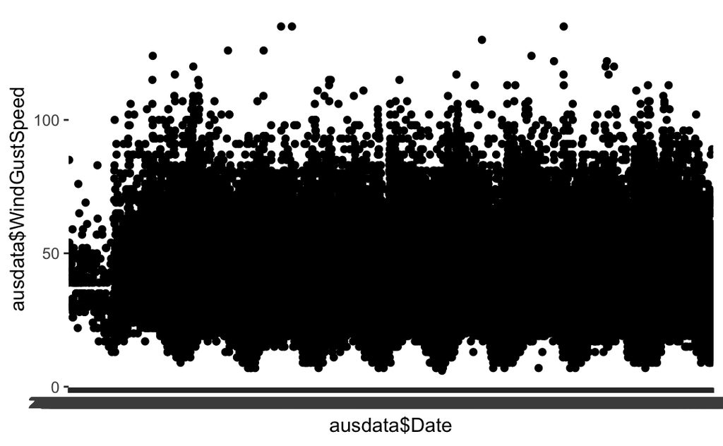

```r
qplot(x = ausdata$Date , y = ausdata$WindGustSpeed)
```

add a line..

```r
cols <- colnames(ausdata)
```

Get rid of the nulls

```r
data_labeled <-  na.omit(ausdata)
```

DropNa(RF, var=c(“dede”)) - drop column

data$dowmdomw[column = value]<- NULL

data <- data[condition]

# 1. Brisbane has faster wind than the rest of austrailia

```r
max(ausdata$Location == "Brisbane", ausdata$WindGustSpeed, na.rm = TRUE)
```

```
[1] 135
```

```r
max(ausdata$Location == "Brisbane", ausdata$WindGustSpeed, na.rm = TRUE)
```

```
[1] 135
```

dataBris <- ausdata[ausdata$Location == “Brisbane”]

```r
dataBris <- ausdata$Location == "Brisbane"
```

```r
summary(dataBris)
```

[output not shown]